# Heart Failure Prediction

### Ejekciona frakcija

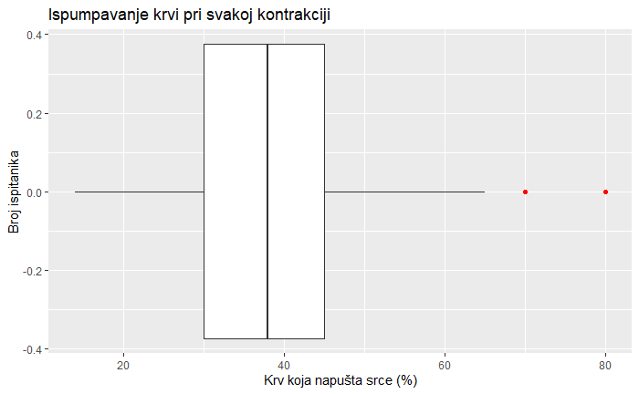

```r
ggplot(data = data, mapping = aes(x = ejection_fraction)) + geom_boxplot(outlier.colour = "red") + labs(title = "Ispumpavanje krvi pri svakoj kontrakciji", x = "Krv koja napušta srce (%)", y = "Broj ispitanika")
```

Sa prikazanog boxplot-a možemo primetiti da imamo vrednosti koje su obeležene kao outlier-i. Međutim, ove vrednosti su itekako moguće i važno je ostaviti ih u skupu iako nisu indikator slabljenja srca. One mogu predstavljati znak nekih drugih oboljenja i mogu pomoći našem modelu prilikom predviđanja otkaza rada srca.

Niske vrednosti mogu predstavljati ozbiljan problem. Ukoliko ejekciona frakcija iznosi 35% ili manje, postoji veliki rizik od razvoja aritmije ili srčane insuficijencije. Bitno je napomenuti da i ljudi sa normalnim vrednostima ejekcione frakcije mogu razviti srčanu slabost.

Na osnovu domenskog znanja, čest je slučaj da srce u većoj ili manjoj meri slabi u starosti. Zato ćemo posmatrati grafik ispod:

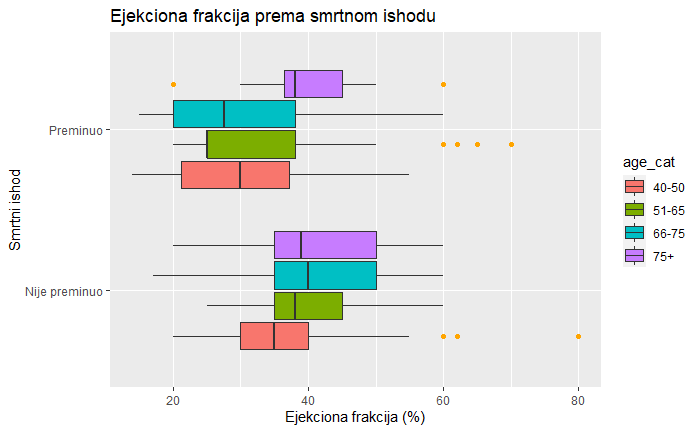

```r
ggplot(data, aes(x = ejection_fraction, y = DEATH_EVENT_cat, fill = age_cat)) +
  geom_boxplot(outlier.colour = "orange") +
  labs(title = "Ejekciona frakcija prema smrtnom ishodu", x = "Ejekciona frakcija (%)", y = "Smrtni ishod")
```

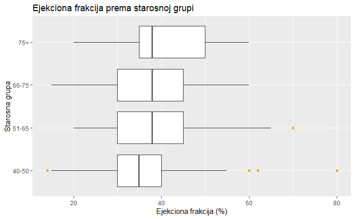

```r
ggplot(data, aes(x = ejection_fraction, y = age_cat)) +
  geom_boxplot(outlier.colour = "orange") +
  labs(title = "Ejekciona frakcija prema starosnoj grupi", x = "Ejekciona frakcija (%)", y = "Starosna grupa")
```

Možemo primetiti da većina ispitanika ima oslabljen rad srca (ispod 50%). Većina odstupanja koja su ucrtana na grafiku zapravo predstavljaju normalne ili povišene vrednosti za ejekcionu frakciju, koje iz iznad navedenih razloga ne bi trebalo ukloniti iz skupa. Imamo i jednu dosta nisku vrednost na grafiku, što znači da je u pitanju ozbiljna srčana insuficijencija, i ta osoba jeste preminula. Na osnovu datih podataka i grafika takođe možemo doći do zaključka da nema značajne korelacije između starosti i oslabljenog rada srca, iako smo pretpostavili da će to biti slučaj.

### Trombociti u krvi

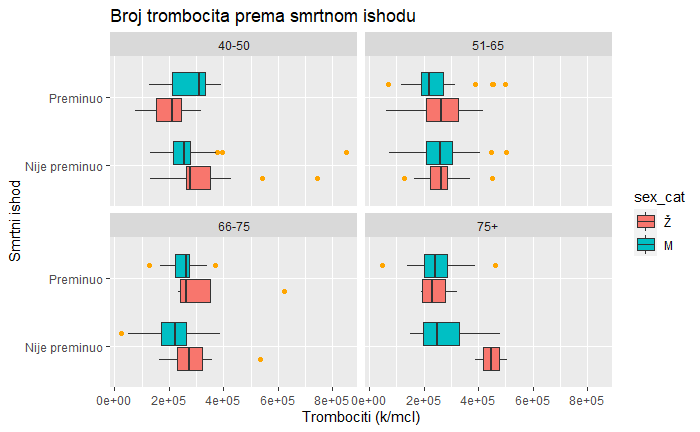

```r
ggplot(data, aes(x = platelets, y = DEATH_EVENT_cat, fill = sex_cat)) +
  geom_boxplot(outlier.colour = "orange") +
  labs(title = "Broj trombocita prema smrtnom ishodu", x = "Trombociti (k/mcl)", y = "Smrtni ishod")+
  facet_wrap(~age_cat,nrow = 2)
```

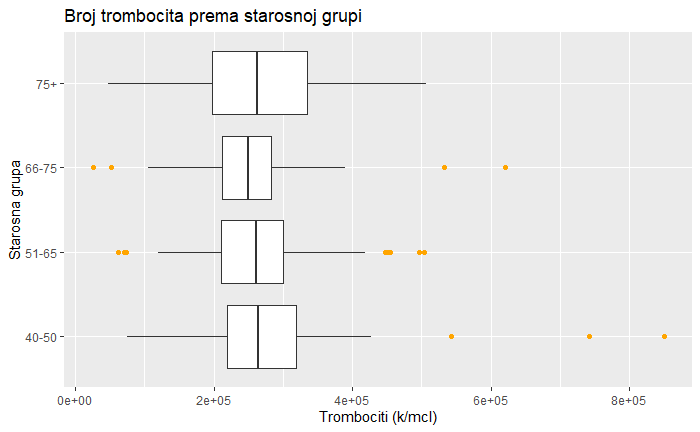

```r
ggplot(data, aes(x = platelets, y = age_cat)) +
  geom_boxplot(outlier.colour = "orange") +
  labs(title = "Broj trombocita prema starosnoj grupi", x = "Trombociti (k/mcl)", y = "Starosna grupa")
```

Normalne vrednosti broja trombocita zavise od starosti i pola ispitanika. Kako čovek stari, broj trombocita koji se proizvodi je sve niži. Kod žena se primećuje nešto manji pad u njihovom broju (domensko znanje). Na grafu, medjutim primećujemo da ženske osobe starosti 75+ ne prate trend naveden iznad. Njihov broj trombocita je viši nego što bi očekivali za tu starosnu grupu. To je verovatno posledica malog uzorka inspitanika koji ovaj skup ima.

Za neke generalne granice normale prilikom testiranja ovog parametra uzimaju se 140000-450000 po mikrolitru.Sa grafika uočavamo da se većina ispitanika nalazi u granicama normale za ovaj parametar. Vrednosti preko 450000 trombocita po mikrolitru se smatraju visokim. Vrednosti ispod 140000 se smatraju niskim i često su praćeni činjenicom da osoba ima anemiju. Poprilično mali broj ispitanika ima neuobičajene vrednosti ovog parametra i kako one mogu da ukazuju na oboljenja koja direktno ili indirektno utiču na heart failure, nećemo ih izbaciti.

### Kreatinin u krvi

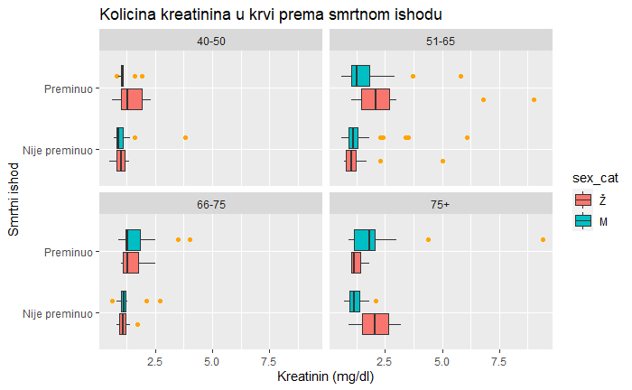

```r
ggplot(data, aes(x = serum_creatinine, y = DEATH_EVENT_cat, fill = sex_cat)) +
  geom_boxplot(outlier.colour = "orange") +
  labs(title = "Količina kreatinina u krvi prema smrtnom ishodu", x = "Kreatinin (mg/dl)", y = "Smrtni ishod")+
  facet_wrap(~age_cat,nrow = 2)
```

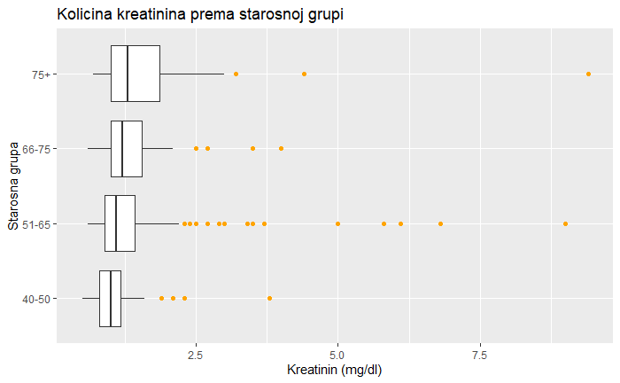

```r
ggplot(data, aes(x = serum_creatinine, y = age_cat)) +
  geom_boxplot(outlier.colour = "orange") +
  labs(title = "Količina kreatinina prema starosnoj grupi", x = "Kreatinin (mg/dl)", y = "Starosna grupa")
```

Kreatinin je takodje parametar koji zavisi od starosti i pola ispitanika. Povećava se tokom godina i obično se u manjim količinama u krvi nalazi kod žena u odnosu na muškarce.

Granice normale se razlikuju za muškarce i žene:

- 0.74-1.35 mg/dl kod muškaraca
- 0.59-1.04 mg/dl kod žena

Sve vrednosti van ovih granica smatraju se niskim, odnosno, visokim. Sa grafika možemo videti da je kreatinin kod većine ispitanika u granicama normale. Skoro sve neuobičajene vrednosti pripadaju visokim vrednostima za kreatinin. Imamo i dve izuzetno visoke vrednosti (veće od 8.5) koje, iako ne toliko česte, nisu nemoguće. Najviša ikad zabeležena koncentracija kreatinina u krvi iznosi 73.8 mg/dl. Kako ovaj parametar može izazvati oboljenja koja mogu uticati na heart failure, nećemo ih otkloniti.

### Natrijum u krvi

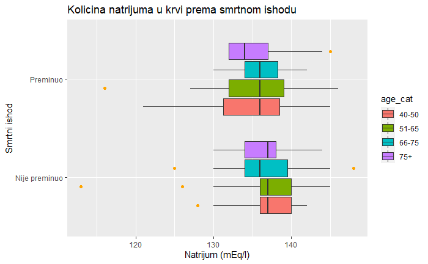

```r
ggplot(data, aes(x = serum_sodium, y = DEATH_EVENT_cat, fill = age_cat)) +
  geom_boxplot(outlier.colour = "orange") +
  labs(title = "Količina natrijuma u krvi prema smrtnom ishodu", x = "Natrijum (mEq/l)", y = "Smrtni ishod")
```

Količina natrijuma u krvi se razlikuje po starosti ispitanika. Za interval normale uzima se 135-145 mEq/l.

Sa grafika zaključujemo da je većina ispitanika u granicama normale. Od nesvakidašnjih vrednosti, većinski imamo one koje su niže od donje granice normale. Ova količina natrijuma smatra se niskom i može biti uzrok srčanih problema, pa ih nećemo izbaciti. Vrednosti veće od gornje granice normale mogu prouzrokovati oboljenja koja mogu uticati na srce, pa ni njih nećemo odstraniti.

# Feature selection

U ovom odeljku ćemo ispitivati u kakvoj su zavisnosti varijable sa ciljnom promenljivom - **DEATH_EVENT**.

```r
xtabs(~DEATH_EVENT_cat, data = data)
```

```
DEATH_EVENT_cat
Nije preminuo      Preminuo
          211           102
```

## Medjusobna zavisnost dve kategorijske varijable

Za utvrđivanje zavisnosti, pored posmatranja grafika, koristićemo i Chi-square (*X<sup>2</sup>*) test. Ovim testom se utvrđuje da li postoji zavisnost između dve kategorijske promenljive. Postavlja se nulta hipoteza - kategorijski parametri su nezavisni. Nakon izvršavanja testa, u zavisnosti od vrednosti parametra p (parametar značajnosti) nultu hipotezu prihvatamo (p > 0.05) odnosno odbacujemo (p < 0.05).

### Zavisnost smrtnog ishoda od anemije

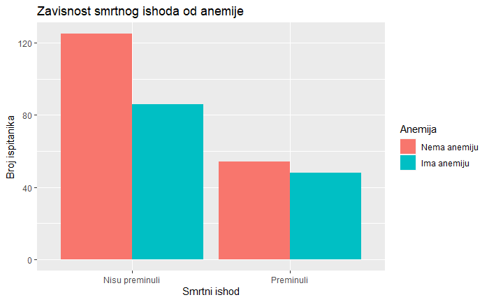

```r
ggplot(data = data) + geom_bar(aes(x=DEATH_EVENT_cat, fill=anaemia_cat), position="dodge") + labs(title ="Zavisnost smrtnog ishoda od anemije", x="Smrtni ishod", y="Broj ispitanika") + scale_x_discrete( labels=c("Nisu preminuli", "Preminuli")) + scale_fill_discrete(name="Anemija")
```

Bilo da posmatramo ispitanike koji su preminuli ili one koji nisu, u oba slučaja više ima onih koji nisu imali anemiju. Za anemiju, koja je sama po sebi zdravstveni problem, možemo reći da ne utiče na našu ciljnu promenljivu. Pogledajmo udeo onih koji su imali anemiju i preminuli:

```r
xtabs(~ DEATH_EVENT_cat + anaemia_cat, data = data)
```

```
               anaemia_cat
DEATH_EVENT_cat Nema anemiju Ima anemiju
  Nije preminuo          125          86
  Preminuo                54          48
```

```r
prop.table(xtabs(~ DEATH_EVENT_cat + anaemia_cat, data = data), margin = 1)
```

```
               anaemia_cat
DEATH_EVENT_cat Nema anemiju Ima anemiju
  Nije preminuo    0.5924171   0.4075829
  Preminuo         0.5294118   0.4705882
```

Od ukupnog broja preminulih ispitanika, oko 47% njih imalo je anemiju. Nešto više od polovine preminulih nije imalo anemiju. Na osnovu ovih podataka možemo zaključiti da anemija ne predstavlja bitan prediktor. To možemo utvrditi na još jedan način - Chi-Squared testom.

```r
chisq.test(data$DEATH_EVENT, data$anaemia)
```

```
    Pearson's Chi-squared test with Yates' continuity correction

data:  data$DEATH_EVENT and data$anaemia
X-squared = 0.87238, df = 1, p-value = 0.3503
```

Na osnovu dobijene vrednosti za p-value, donosimo zaključak da anemija **ne utiče** na izlaznu promenljivu.

### Zavisnost smrtnog ishoda od dijabetesa

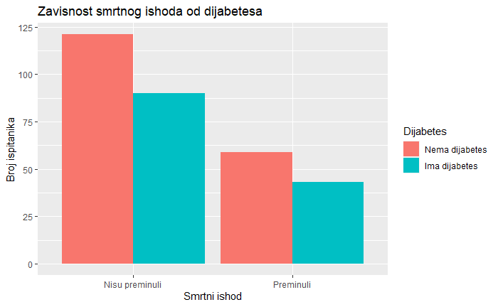

```r
ggplot(data = data) + geom_bar(aes(x=DEATH_EVENT_cat, fill=diabetes_cat), position="dodge") + labs(title ="Zavisnost smrtnog ishoda od dijabetesa", x="Smrtni ishod", y="Broj ispitanika") + scale_x_discrete( labels=c("Nisu preminuli", "Preminuli")) + scale_fill_discrete(name="Dijabetes")
```

Na osnovu grafika zapažamo gotovo identičan slučaj kao kod ispitivanja zavisnosti smrtnog ishoda od anemije. Većina preminulih pacijenata, kao i preživelih, nisu imali dijabetes. Pogledaćemo i udeo ovih vrednosti.

```r
prop.table(xtabs(~ DEATH_EVENT_cat + diabetes_cat, data = data), margin = 1)
```

```
               diabetes_cat
DEATH_EVENT_cat Nema dijabetes Ima dijabetes
  Nije preminuo      0.5734597     0.4265403
  Preminuo           0.5784314     0.4215686
```

Od ukupnog broja preminulih pacijenata, oko 42% njih imalo je dijabetes. Već na osnovu ovoga možemo zaključiti da ni dijabetes ne predstavlja značajan parametar za predviđanje smrtnog ishoda, ali ćemo ponovo našu pretpostavku proveriti Chi-Squared testom.

```r
chisq.test(data$DEATH_EVENT, data$diabetes)
```

```
    Pearson's Chi-squared test with Yates' continuity correction

data:  data$DEATH_EVENT and data$diabetes
X-squared = 0, df = 1, p-value = 1
```

Dobijamo da dijabetes zaista **ne utiče** na izlaznu promenljivu.

### Zavisnost smrtnog ishoda od hipertenzije

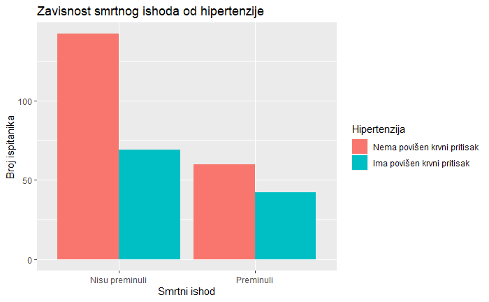

```r
ggplot(data = data) + geom_bar(aes(x=DEATH_EVENT_cat, fill=high_blood_pressure_cat), position="dodge") + labs(title ="Zavisnost smrtnog ishoda od hipertenzije", x="Smrtni ishod", y="Broj ispitanika") + scale_x_discrete( labels=c("Nisu preminuli", "Preminuli")) + scale_fill_discrete(name="Hipertenzija")
```

Ponovo, najmanje u skupu imamo onih ispitanika koji su imali hipertenziju i preminuli. Udeo ćemo pogledati ispod:

```r
prop.table(xtabs(~ DEATH_EVENT_cat + high_blood_pressure_cat, data = data), margin = 1)
```

```
               high_blood_pressure_cat
DEATH_EVENT_cat Nema povišen krvni pritisak Ima povišen krvni pritisak
  Nije preminuo                   0.6729858                  0.3270142
  Preminuo                        0.5882353                  0.4117647
```

41% ispitanika koji su preminuli imali su povišen krvni pritisak.

```r
chisq.test(data$DEATH_EVENT, data$high_blood_pressure)
```

```
    Pearson's Chi-squared test with Yates' continuity correction

data:  data$DEATH_EVENT and data$high_blood_pressure
X-squared = 1.8035, df = 1, p-value = 0.1793
```

Vrednost za p-value je veća od 0.05, čime dokazujemo hipotezu da su promenljive high_blood_pressure i DEATH_EVENT nezavisne. Drugim rečima, ni hipertenzija **ne predstavlja bitan prediktor**.

### Zavisnost smrtnog ishoda od pola

```r
prop.table(xtabs(~sex_cat + DEATH_EVENT_cat, data = data), margin = 1)
```

```
       DEATH_EVENT_cat
sex_cat Nije preminuo  Preminuo
      Ž     0.6788991 0.3211009
      M     0.6715686 0.3284314
```

Uočavamo da procentualno jednak broj muškaraca umire od otkazivanja srca koliko i žena.

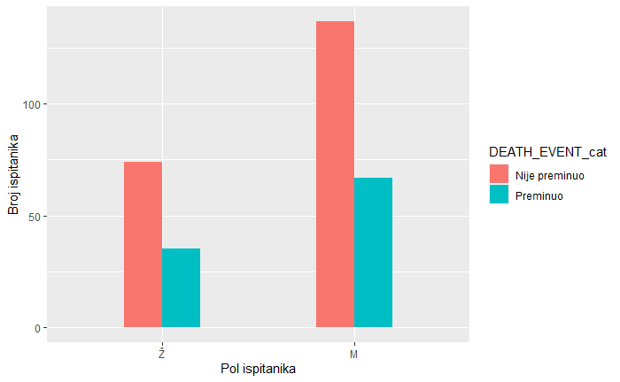

```r
ggplot(data, aes(x = sex_cat, fill=DEATH_EVENT_cat)) +
geom_bar(position = "dodge", width = 0.4) +
ylab("Broj ispitanika") +
xlab("Pol ispitanika")
```

I sa grafa vidimo da pol nema neki uticaj na smrtni ishod ispitanika. Da bi bili sigurni, proverićemo i Chi-sqare testom.

```r
chisq.test(data$DEATH_EVENT, data$sex)
```

```
    Pearson's Chi-squared test with Yates' continuity correction

data:  data$DEATH_EVENT and data$sex
X-squared = 2.7633e-05, df = 1, p-value = 0.9958
```

Vidimo da je vrednost parametra p veća od 0.05, dakle prihvatamo nultu hipotezu - smrtni ishod i pol su nezavisni. Dakle, pol **nećemo uzimati u obzir** prilikom pravljenja modela.

### Zavisnost smrtnog ishoda od pušenja

```r
prop.table(xtabs(~smoking_cat + DEATH_EVENT_cat, data = data), margin = 1)
```

```
           DEATH_EVENT_cat
smoking_cat Nije preminuo  Preminuo
         Ne     0.6745283 0.3254717
         Da     0.6732673 0.3267327
```

Uvočavamo sličnu situaciju kao sa polom. Da li je ispitanik pušač ili ne najverovatnije neće uticati na smrtni ishod. Prikazaćemo i grafikom, a zatim potvrditi i testom.

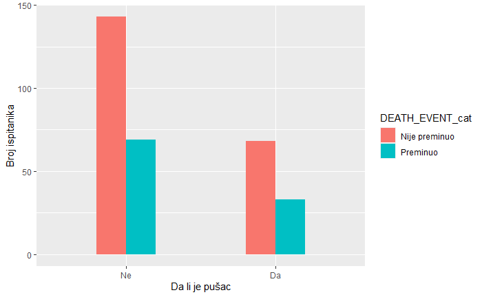

```r
ggplot(data, aes(x = smoking_cat, fill=DEATH_EVENT_cat)) +
geom_bar(position = "dodge", width = 0.4) +
ylab("Broj ispitanika") +
xlab("Da li je pušač")
```

```r
chisq.test(data$DEATH_EVENT, data$smoking)
```

```
    Pearson's Chi-squared test with Yates' continuity correction

data:  data$DEATH_EVENT and data$smoking
X-squared = 0, df = 1, p-value = 1
```

Vrednost parametra p je veća od 0.05, dakle, pušenje zaista **neće uticati** na smrtni ishod.

S obzirom na to da nijedna kategorijska varijabla sama po sebi ne utiče na ciljnu promenljivu, proverićemo da li možda postoji zavisnost između neke njihove kombinacije i izlazne promenljive. Kako bismo ovo utvrdili, vizuelizaciju ćemo obaviti preko **mosaic** plot-a. Mosaic plot je pogodno koristiti u situacijama kada želimo da proverimo zavisnost između više kategorijskih varijabli. Početnom hipotezom pretpostavićemo da su varijable nezavisne. Ako pravougaonici na grafiku ne budu obojeni, to će značiti da je naša hipoteza tačna, tj. nema zavisnosti između posmatranih varijabli. Boje koje se mogu pojaviti na grafiku su plava i crvena i one označavaju zavisnost (plava označava da ima više slučajeva nego što se očekivalo, crvena označava manje slučajeva nego što se očekivalo).

### Zavisnost smrtnog ishoda od anemije i dijabetesa

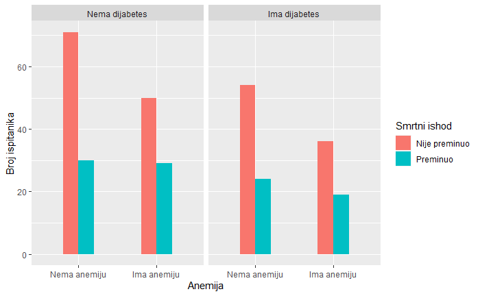

```r
ggplot(data, aes(x = anaemia_cat, fill=DEATH_EVENT_cat)) + geom_bar(position = "dodge", width = 0.4) + ylab("Broj ispitanika") + xlab("Anemija") + facet_wrap(~diabetes_cat) + scale_fill_discrete(name="Smrtni ishod")
```

Na osnovu barplot-a možemo pretpostaviti da nema neke bitne zavisnosti između varijabli. Pogledaćemo i mosaic plot.

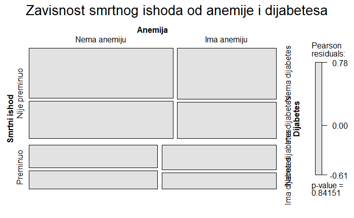

```r
zavisnost = xtabs(~DEATH_EVENT_cat + anaemia_cat + diabetes_cat, data = data)

mosaic(zavisnost, shade = TRUE, legend = TRUE, labeling_args = list(set_varnames = c(anaemia_cat = "Anemija", DEATH_EVENT_cat = "Smrtni ishod", diabetes_cat = "Dijabetes")), main = "Zavisnost smrtnog ishoda od anemije i dijabetesa")
```

Kako na grafiku nemamo ni plavu a ni crvenu boju, posmatrane varijable su zaista **nezavisne**.

### Zavisnost smrtnog ishoda od anemije i povišenog krvnog pritiska

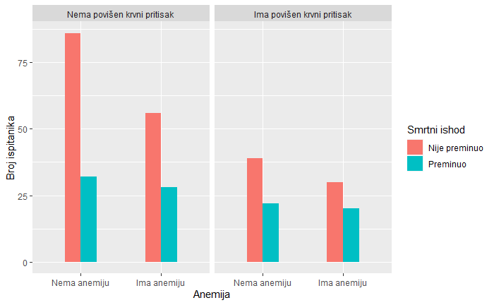

```r
ggplot(data, aes(x = anaemia_cat, fill=DEATH_EVENT_cat)) + geom_bar(position = "dodge", width = 0.4) + ylab("Broj ispitanika") + xlab("Anemija") + facet_wrap(~high_blood_pressure_cat) + scale_fill_discrete(name="Smrtni ishod")
```

Slično kao ranije, ne uočava se zavisnost, ali ćemo to proveriti.

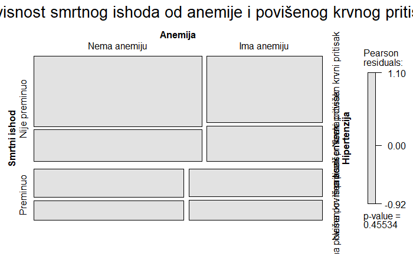

```r
zavisnost = xtabs(~DEATH_EVENT_cat + anaemia_cat + high_blood_pressure_cat, data = data)

mosaic(zavisnost, shade = TRUE, legend = TRUE, labeling_args = list(set_varnames = c(anaemia_cat = "Anemija", DEATH_EVENT_cat = "Smrtni ishod", high_blood_pressure_cat = "Hipertenzija")), main = "Zavisnost smrtnog ishoda od anemije i povišenog krvnog pritiska")
```

Zaključak je da **nemamo zavisnost** između posmatranih promenljivih.

### Zavisnost smrtnog ishoda od anemije i pušenja

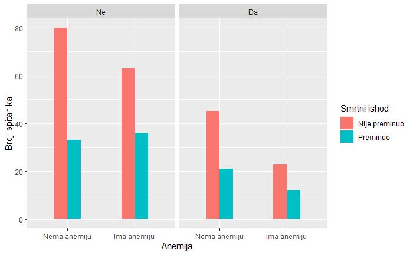

```r
ggplot(data, aes(x = anaemia_cat, fill=DEATH_EVENT_cat)) + geom_bar(position = "dodge", width = 0.4) + ylab("Broj ispitanika") + xlab("Anemija") + facet_wrap(~smoking_cat) + scale_fill_discrete(name="Smrtni ishod")
```

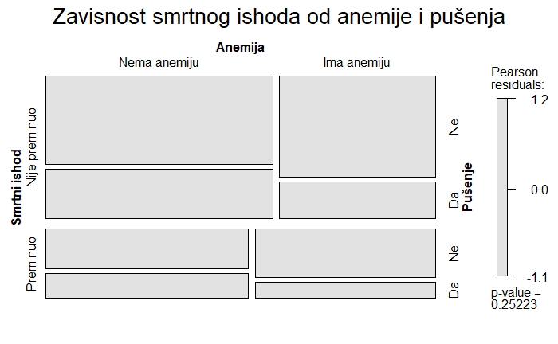

```r
zavisnost = xtabs(~DEATH_EVENT_cat + anaemia_cat + smoking_cat, data = data)

mosaic(zavisnost, shade = TRUE, legend = TRUE, labeling_args = list(set_varnames = c(anaemia_cat = "Anemija", DEATH_EVENT_cat = "Smrtni ishod", smoking_cat = "Pušenje")), main = "Zavisnost smrtnog ishoda od anemije i pušenja")
```

Ponovo **nemamo zavisnost**.

### Zavisnost smrtnog ishoda od anemije i pola

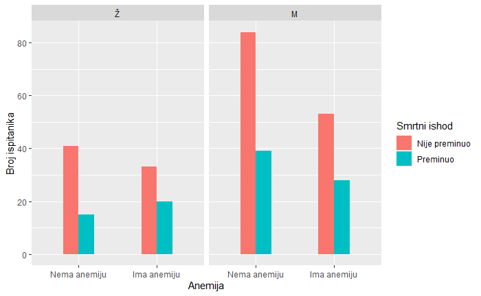

```r
ggplot(data, aes(x = anaemia_cat, fill=DEATH_EVENT_cat)) + geom_bar(position = "dodge", width = 0.4) + ylab("Broj ispitanika") + xlab("Anemija") + facet_wrap(~sex_cat) + scale_fill_discrete(name="Smrtni ishod")
```

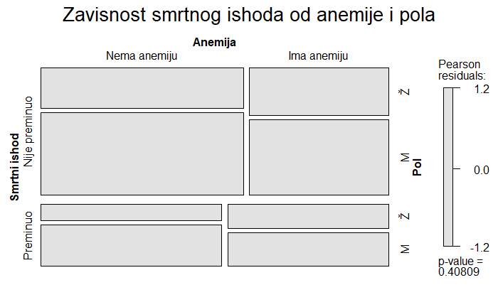

```r
zavisnost = xtabs(~DEATH_EVENT_cat + anaemia_cat + sex_cat, data = data)

mosaic(zavisnost, shade = TRUE, legend = TRUE, labeling_args = list(set_varnames = c(anaemia_cat = "Anemija", DEATH_EVENT_cat = "Smrtni ishod", sex_cat = "Pol")), main = "Zavisnost smrtnog ishoda od anemije i pola")
```

Ni u ovom slučaju **nemamo zavisnost**.

### Zavisnost smrtnog ishoda od dijabetesa i pritiska

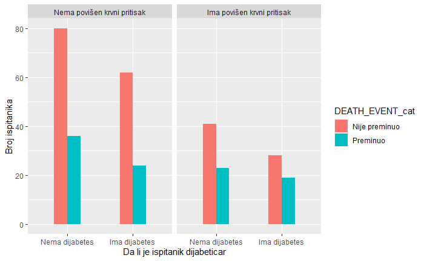

```r
ggplot(data, aes(x = diabetes_cat, fill=DEATH_EVENT_cat)) +
  geom_bar(position = "dodge", width = 0.4) +
  ylab("Broj ispitanika") +
  xlab("Da li je ispitanik dijabetičar")+
  facet_wrap(~high_blood_pressure_cat)
```

Sa grafika vidimo da je odnos preminulih i živih konstantan u podnosu na pritisak i dijabetes. Zaključujemo da kombinacija ova dva faktora **ne utiče** na smrtni ishod.

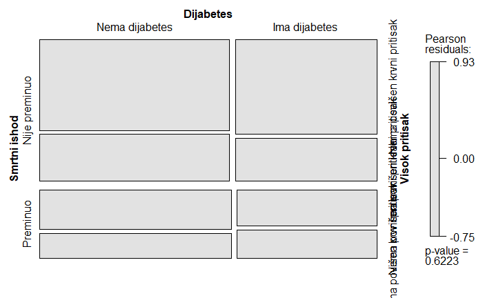

```r
zavisnost <- xtabs(~DEATH_EVENT_cat + diabetes_cat + high_blood_pressure_cat, data)

mosaic(zavisnost, shade = TRUE, legend = TRUE, labeling_args = list(set_varnames = c(DEATH_EVENT_cat = "Smrtni ishod", diabetes_cat = "Dijabetes", high_blood_pressure_cat = "Visok pritisak")))
```

### Zavisnost smrtnog ishoda od dijabetesa i pušenja

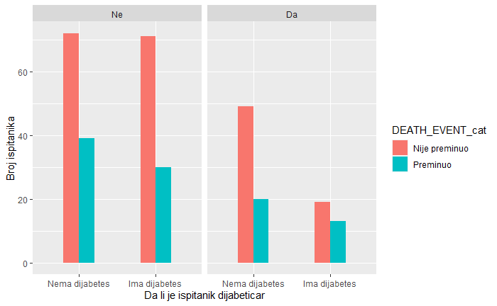

```r
ggplot(data, aes(x = diabetes_cat, fill=DEATH_EVENT_cat)) +
  geom_bar(position = "dodge", width = 0.4) +
  ylab("Broj ispitanika") +
  xlab("Da li je ispitanik dijabetičar")+
  facet_wrap(~smoking_cat)
```

Sa grafika vidimo da je odnos preminulih i živih konstantan u podnosu na pušenje i dijabetes. Zaključujemo da kombinacija ova dva faktora **ne utiče** na smrtni ishod.

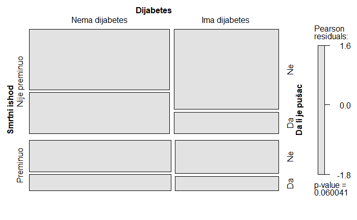

```r
zavisnost <- xtabs(~DEATH_EVENT_cat + diabetes_cat + smoking_cat, data)

mosaic(zavisnost, shade = TRUE, legend = TRUE, labeling_args = list(set_varnames = c(DEATH_EVENT_cat = "Smrtni ishod", diabetes_cat = "Dijabetes", smoking_cat = "Da li je pušač")))
```

### Zavisnost smrtnog ishoda od dijabetesa i pola

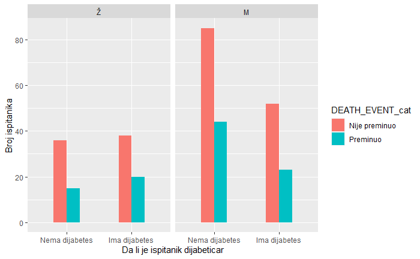

```r
ggplot(data, aes(x = diabetes_cat, fill=DEATH_EVENT_cat)) +
  geom_bar(position = "dodge", width = 0.4) +
  ylab("Broj ispitanika") +
  xlab("Da li je ispitanik dijabetičar")+
  facet_wrap(~sex_cat)
```

Sa grafika vidimo da je odnos preminulih i živih konstantan u podnosu na pol i dijabetes. Zaključujemo da kombinacija ova dva faktora **ne utiče** na smrtni ishod.

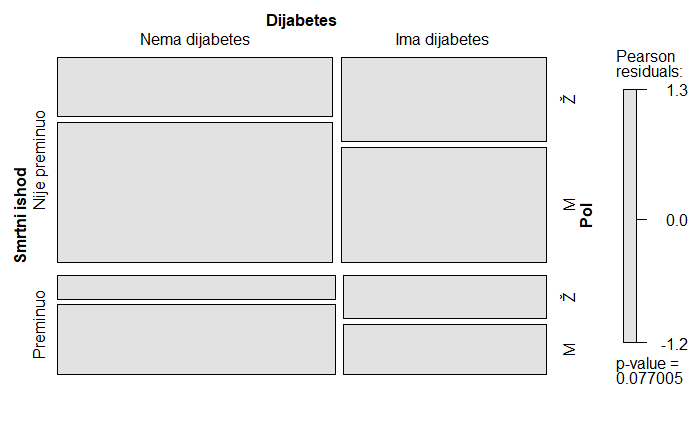

```r
zavisnost <- xtabs(~DEATH_EVENT_cat + diabetes_cat + sex_cat, data)

mosaic(zavisnost, shade = TRUE, legend = TRUE, labeling_args = list(set_varnames = c(DEATH_EVENT_cat = "Smrtni ishod", diabetes_cat = "Dijabetes", sex_cat = "Pol")))
```

### Zavisnost smrtnog ishoda od visokog krvnog pritiska i pušenja

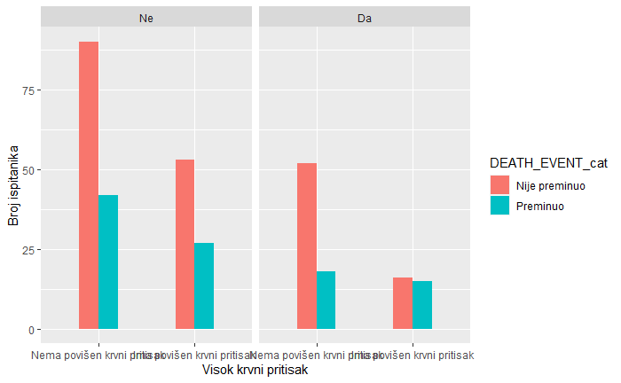

```r
ggplot(data, aes(x = high_blood_pressure_cat, fill=DEATH_EVENT_cat)) +
  geom_bar(position = "dodge", width = 0.4) +
  ylab("Broj ispitanika") +
  xlab("Visok krvni pritisak")+
  facet_wrap(~smoking_cat)
```

Sa grafika vidimo da je odnos preminulih i živih konstantan u podnosu na pritisak i pušenje. Kod pušača sa povišenim pritiskom primećujemo da su približno brojevi preminulih i onih koji nisu. Proverićemo i pomoći mosaic-a.

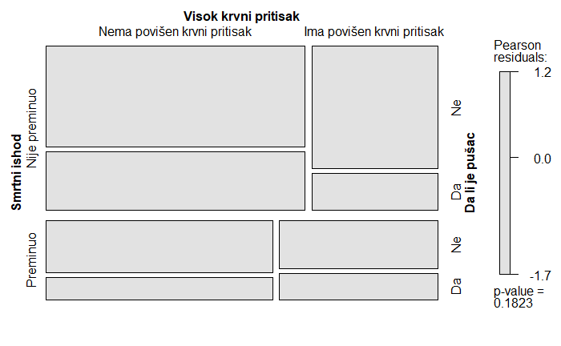

```r
zavisnost <- xtabs(~DEATH_EVENT_cat + high_blood_pressure_cat + smoking_cat, data)

mosaic(zavisnost, shade = TRUE, legend = TRUE, labeling_args = list(set_varnames = c(DEATH_EVENT_cat = "Smrtni ishod", high_blood_pressure_cat = "Visok krvni pritisak", smoking_cat = "Da li je pušač")))
```

Ne uočavamo nikakvu boju na grafiku što nam daje do znanja da kombinacija ova dva parametra **ne utiče** na smrtni ishod.

### Zavisnost smrtnog ishoda od visokog krvnog pritiska i pola

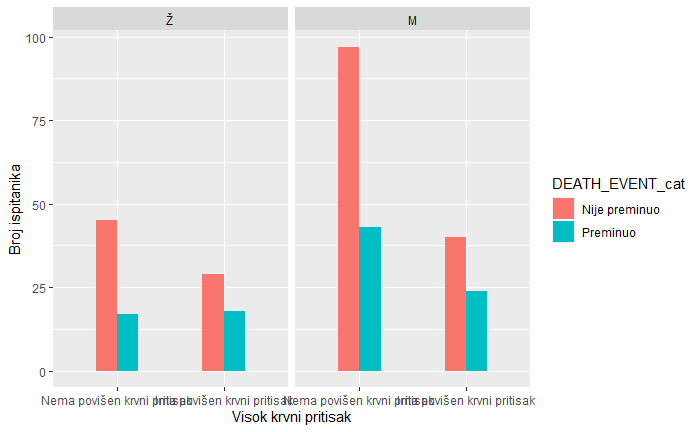

```r
ggplot(data, aes(x = high_blood_pressure_cat, fill=DEATH_EVENT_cat)) +
  geom_bar(position = "dodge", width = 0.4) +
  ylab("Broj ispitanika") +
  xlab("Visok krvni pritisak")+
  facet_wrap(~sex_cat)
```

Sa grafika vidimo da je odnos preminulih i živih konstantan u podnosu na pol i povišen krvni pritisak Zaključujemo da kombinacija ova dva faktora **ne utiče** na smrtni ishod.

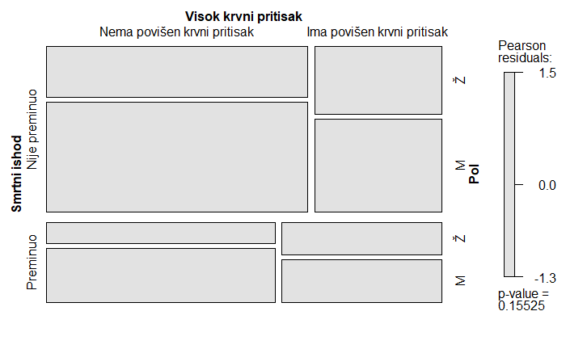

```r
zavisnost <- xtabs(~DEATH_EVENT_cat + high_blood_pressure_cat + sex_cat, data)

mosaic(zavisnost, shade = TRUE, legend = TRUE, labeling_args = list(set_varnames = c(DEATH_EVENT_cat = "Smrtni ishod", high_blood_pressure_cat = "Visok krvni pritisak", sex_cat = "Pol")))
```

### Zavisnost smrtnog ishoda od pušenja i pola

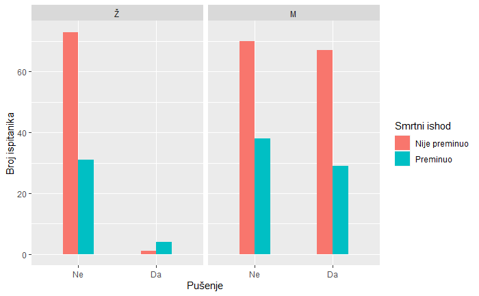

```r
ggplot(data, aes(x = smoking_cat, fill=DEATH_EVENT_cat)) + geom_bar(position = "dodge", width = 0.4) + ylab("Broj ispitanika") + xlab("Pušenje") + facet_wrap(~sex_cat) + scale_fill_discrete(name="Smrtni ishod")
```

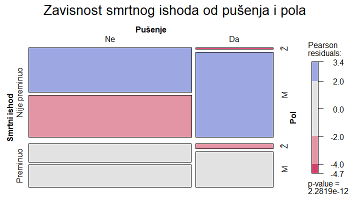

```r
zavisnost = xtabs(~DEATH_EVENT_cat + smoking_cat + sex_cat, data = data)

mosaic(zavisnost, shade = TRUE, legend = TRUE, labeling_args = list(set_varnames = c(smoking_cat = "Pušenje", DEATH_EVENT_cat = "Smrtni ishod", sex_cat = "Pol")), main = "Zavisnost smrtnog ishoda od pušenja i pola")
```

Kada su varijable pušenje i pol u kombinaciji sa smrtnim ishodom, primećujemo značajnu obojenost grafika. I na osnovu prethodnog barplot-a možemo uočiti jednu situaciju koju nismo imali pre - u grupi ispitanika koji su ženskog pola i pušači po prvi put imamo slučaj da je većina ljudi preminula, ali isto tako vidimo da imamo jako mali broj osoba u toj grupi. To je verovatno posledica toga što imamo relativno mali broj ispitanika. Uzimajući ovo u obzir, **nećemo posmatrati pol i pušenje kao bitne faktore zajedno**, jer je zavisnost koju uočavamo sa mozaika vrlo verovatno posledica nekakvog trenda u skupu koji nema mnogo veze sa realnom slikom.

## Međusobna zavisnost numeričke i kategorijske promenljive

Da bismo utvrdili da li smrtni ishod zavisi od posmatranih numeričkih parametara, posmatraćemo grafove i upotrebiti Kruskal-Wallis test. Ovim testom ispitujemo zavisnost numeričke i kategorijske varijable i kao rezultat dobijamo Kruskal-Wallis Chi-square parametar i parametar značajnosti - p. Identično kao kod Chi-square testa, postavljamo hitpotezu da su varijable nezavisne. Ukoliko je vrednost parametra p veća od 0.05, hipoteza se prihvata. U suprotnom se odbacuje i zaključujemo da zavisnost postoji.

### Zavisnost smrtnog ishoda od starosti

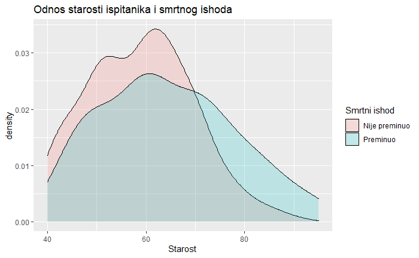

```r
ggplot(data, aes(x = age, fill = DEATH_EVENT_cat)) + geom_density(alpha = 0.2) + labs(title = "Odnos starosti ispitanika i smrtnog ishoda", x="Starost") + scale_fill_discrete(name="Smrtni ishod")
```

U obe grupe ispitanika (i oni koji su preminuli i oni koji nisu) imamo visoke vrednosti za godine, pa samim tim ne možemo sa sigurnošću reći da će ljudi sa više od određenog broja godina sigurno preminuti. Međutim, ako pogledamo površine ispod grafika, negde od 70. godine života pa naviše je veća šansa da će osoba preminuti. Isto tako, ispod 70 godina je nešto veća šansa da će preživeti. Proverićemo ovo i preko boxplot-a.

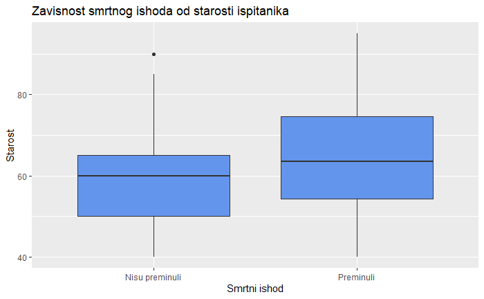

```r
ggplot(data, aes(x = DEATH_EVENT_cat, y = age)) + geom_boxplot(fill = "cornflowerblue") + labs(title = "Zavisnost smrtnog ishoda od starosti ispitanika", x="Smrtni ishod", y="Starost") + scale_x_discrete( labels=c("Nisu preminuli", "Preminuli"))
```

Na osnovu dobijenog grafika, možemo utvrditi da je vrednost medijane kod preminulih viša nego kod ispitanika koji nisu preminuli, ali ne drastično. Možemo na osnovu toga i interkvatilnog rastojanja pretpostaviti da su uglavnom stariji pacijenti imali manje šanse da prežive.

Uzimajući u obzir zaključke koje smo izveli na osnovu ova dva grafika, možemo pretpostaviti da starost potencijalno može biti značajan za predikciju (naročito ukoliko se iskombinuje sa još nekim parametrima, ali to će biti analizirano u nastavku). Kako bismo proverili da li starost predstavlja bitan prediktor, sprovešćemo Kruskal-Wallis test.

```r
kruskal.test(x = data$age, g = data$DEATH_EVENT_cat)
```

```
    Kruskal-Wallis rank sum test

data:  data$age and data$DEATH_EVENT_cat
Kruskal-Wallis chi-squared = 10.589, df = 1, p-value = 0.001138
```

Kako dobijamo da je p-value < 0.05, odbacujemo nultu hipotezu da su varijable starost i smtrni ishod nezavisne, čime dolazimo do zaključka da starost **utiče** na našu ciljnu promenljivu.

### Zavisnost smrtnog ishoda od vrednosti CPK enzima

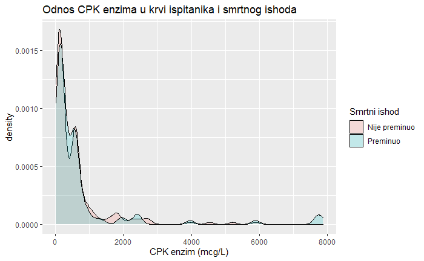

```r
ggplot(data, aes(x = creatinine_phosphokinase, fill = DEATH_EVENT_cat)) + geom_density(alpha = 0.2) + labs(title = "Odnos CPK enzima u krvi ispitanika i smrtnog ishoda", x="CPK enzim (mcg/L)") + scale_fill_discrete(name="Smrtni ishod")
```

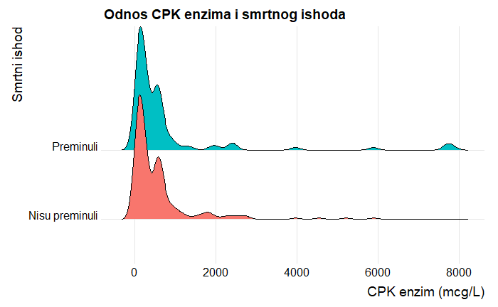

```r
ggplot(data, aes(x = creatinine_phosphokinase, y = DEATH_EVENT_cat, fill = DEATH_EVENT_cat)) + geom_density_ridges() + theme_ridges() + labs(title = "Odnos CPK enzima i smrtnog ishoda", x = "CPK enzim (mcg/L)", y = "Smrtni ishod") + theme(legend.position = "none") + scale_y_discrete( labels=c("Nisu preminuli", "Preminuli"))
```

Kao što je iznad navedeno, ispitanici sa ekstremno visokim vrednostima CPK enzima su preminuli.

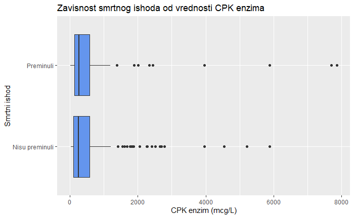

```r
ggplot(data, aes(x = creatinine_phosphokinase, y = DEATH_EVENT_cat)) + geom_boxplot(fill = "cornflowerblue") + labs(title = "Zavisnost smrtnog ishoda od vrednosti CPK enzima", x="CPK enzim (mcg/L)", y="Smrtni ishod") + scale_y_discrete( labels=c("Nisu preminuli", "Preminuli"))
```

Medijane su gotovo na identičnoj poziciji. Za ispitanike sa dve najveće vrednosti CPK enzima u skupu možemo primetiti da su preminuli. Međutim, već na osnovu grafika možemo pretpostaviti da CPK enzim verovatno ne predstavlja značajan parametar za predviđanje izlazne promenljive. Kako bismo ovo proverili, ponovo sprovodimo Kruskal-Wallis test.

```r
kruskal.test(x = data$creatinine_phosphokinase, g = data$DEATH_EVENT_cat)
```

```
    Kruskal-Wallis rank sum test

data:  data$creatinine_phosphokinase and data$DEATH_EVENT_cat
Kruskal-Wallis chi-squared = 0.24953, df = 1, p-value = 0.6174
```

Dobijamo vrednost za p-value koja je veća od 0.05, čime smo potvrdili da ne postoji zavisnost između vrednosti CPK enzima u krvi i smrtnog ishoda, odnosno CPK enzim zaista **ne predstavlja bitan prediktor**.

### Zavisnost smrtnog ishoda od ejekcione frakcije

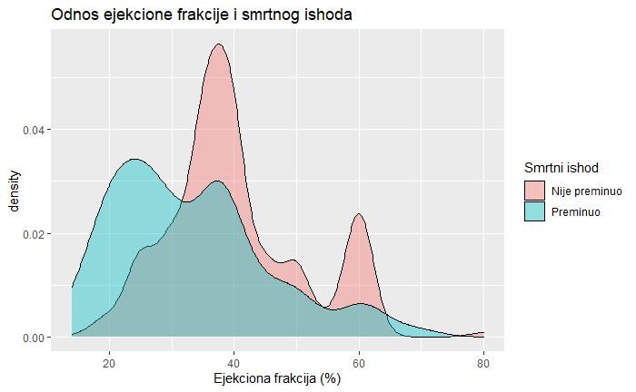

```r
ggplot(data, aes(x = ejection_fraction, fill = DEATH_EVENT_cat)) + geom_density(alpha = 0.4) + labs(title = "Odnos ejekcione frakcije i smrtnog ishoda", x="Ejekciona frakcija (%)") + scale_fill_discrete(name="Smrtni ishod")
```

Na osnovu density plot-a, možemo primetiti da je većina ispitanika sa ejekcionom fakcijom ispod (odokativno) 32% preminula. Pogledaćemo i raspodelu na boxplot-u.

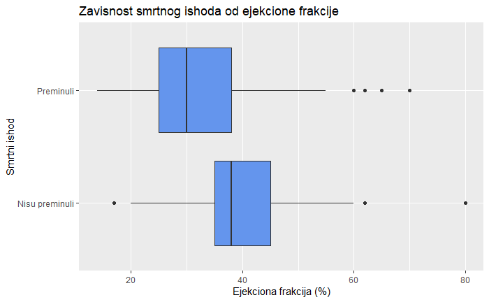

```r
ggplot(data, aes(x = ejection_fraction, y = DEATH_EVENT_cat)) + geom_boxplot(fill = "cornflowerblue") + labs(title = "Zavisnost smrtnog ishoda od ejekcione frakcije", x="Ejekciona frakcija (%)", y="Smrtni ishod") + scale_y_discrete( labels=c("Nisu preminuli", "Preminuli"))
```

Sa ovog grafika još bolje možemo uočiti da su u globalu preminuli ispitanici imali niže vrednosti za ejekcionu frakciju u odnosu na preživele. Medijane za ove dve grupe ispitanika se poprilično razlikuju, za razliku od slučajeva iznad kada smo posmatrali starost i CPK enzim, gde su bile dosta slične. Na osnovu ovoga, ejekciona frakcija potencijalno može biti bitan prediktor za model koji ćemo kasnije napraviti. Kako bismo bili sigurni u ovu pretpostavku, pobovo sprovodimo Kruskal-Wallis test.

```r
kruskal.test(x = data$ejection_fraction, g = data$DEATH_EVENT_cat)
```

```
    Kruskal-Wallis rank sum test

data:  data$ejection_fraction and data$DEATH_EVENT_cat
Kruskal-Wallis chi-squared = 26.96, df = 1, p-value = 2.077e-07
```

Ipak, ovim testom dobijamo odbacujemo nultu hipotezu - da su ejekciona frakcija i smrtni ishod nezavisne varijable. Ejekciona frakcija **utiče** na ciljnu promenljivu.

### Zavisnost smrtnog ishoda i broja trombocita u krvi

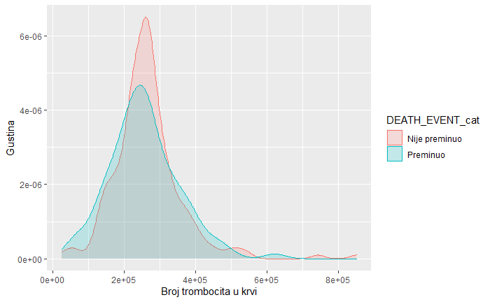

```r
ggplot(data, aes(x=platelets,colour=DEATH_EVENT_cat,fill=DEATH_EVENT_cat))+
  geom_density(alpha=0.2)+
  scale_y_continuous(name = "Gustina")+
  scale_x_continuous(name = "Broj trombocita u krvi")
```

Na grafiku vidimo da u suštini nema velike razlike u nivoima trombocita kod preminulih ispitanika i onih koji nisu. Da bismo sigurno utvrdili da li zavisnost ne postoji, odradićemo Kruskal-Wallis test.

```r
kruskal.test(x = data$platelets, g = data$DEATH_EVENT_cat)
```

```
    Kruskal-Wallis rank sum test

data:  data$platelets and data$DEATH_EVENT_cat
Kruskal-Wallis chi-squared = 0.73805, df = 1, p-value = 0.3903
```

Vrednost parametra p nam je veća od 0.05 što znači da prihvatamo nultu hipotezu. Broj trombocita u krvi **ne utiče** na smrtni ishod.

### Zavisnost smrtnog ishoda i nivoa kreatinina u krvi

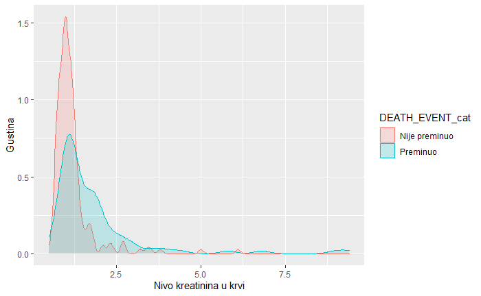

```r
ggplot(data, aes(x=serum_creatinine,colour=DEATH_EVENT_cat,fill=DEATH_EVENT_cat))+
  geom_density(alpha=0.2)+
  scale_y_continuous(name = "Gustina")+
  scale_x_continuous(name = "Nivo kreatinina u krvi")
```

```r
kruskal.test(x = data$serum_creatinine, g = data$DEATH_EVENT_cat)
```

```
    Kruskal-Wallis rank sum test

data:  data$serum_creatinine and data$DEATH_EVENT_cat
Kruskal-Wallis chi-squared = 40.009, df = 1, p-value = 2.528e-10
```

Kao rezultat testa dobijamo vrednost parametra p koja je manja od 0.05, što nam ukazuje da **nivo kreatinina jeste bitan parametar za predikciju smrtnog ishoda**.

### Zavisnost smrtnog ishoda i nivoa natrijuma u krvi

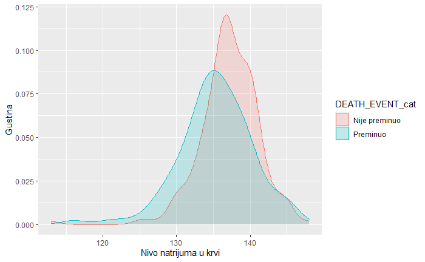

```r
ggplot(data, aes(x=serum_sodium,colour=DEATH_EVENT_cat,fill=DEATH_EVENT_cat))+
  geom_density(alpha=0.2)+
  scale_y_continuous(name = "Gustina")+
  scale_x_continuous(name = "Nivo natrijuma u krvi")
```

Sa grafika vidimo da preminuli ispitanici imaju niže količine natrijuma u krvi. Potencijalno bi količina natrijuma mogla da utiče na smrtni ishod pa ćemo odraditi test da to potvrdimo.

```r
kruskal.test(x = data$serum_sodium, g = data$DEATH_EVENT_cat)
```

```
    Kruskal-Wallis rank sum test

data:  data$serum_sodium and data$DEATH_EVENT_cat
Kruskal-Wallis chi-squared = 13.224, df = 1, p-value = 0.0002763
```

Vrednost za parametar p koji dobijemo je manja od 0.05. Dakle i **količina natrijuma jeste bitan parametar prilikom predvidjanja smrtnog ishoda**.

### Zavisnost smrtnog ishoda i propratnog perioda

Propratni period predstavlja broj dana posmatranja pacijenta nakon pregleda. Kao takav, nema nikakav uticaj na smrtni ishod ispitanika pa nećemo analizirati zavisnost.

# Modeli mašinskog učenja

## Podela skupa na trening i test

Skup podata ćemo podeliti na trening i testni skup u odnosu 80:20. Uzećemo nasumične vrste za oba skupa.

```r
sample_size = floor(0.8*nrow(data))
set.seed(10)
train_ind = sample(seq_len(nrow(data)), size = sample_size)
```

Izvojićemo parametre (kolone) koje su nam značajne za predikciju smrtnog ishoda.

```r
parametri = c('age','ejection_fraction','serum_creatinine','serum_sodium','DEATH_EVENT')
data_prediction=data[parametri]

train = data_prediction[train_ind, ]
test = data_prediction[-train_ind, ]
```

Da pogledamo kako nam izgledaju trening i test skupovi.

```r
str(train)
```

```
'data.frame':   250 obs. of  5 variables:
 $ age              : num  65 58 70 44 50 53 45 45 65 60 ...
 $ ejection_fraction: int  60 35 17 30 30 60 30 35 25 30 ...
 $ serum_creatinine : num  0.9 0.9 1 1.6 0.9 0.8 1.1 1.3 1.4 1.7 ...
 $ serum_sodium     : int  137 139 136 130 132 135 137 142 129 127 ...
 $ DEATH_EVENT      : int  0 0 0 0 0 0 1 0 1 1 ...
```

```r
str(test)
```

```
'data.frame':   63 obs. of  5 variables:
 $ age              : num  55 65 75 87 65 50 90 70 72 60 ...
 $ ejection_fraction: int  38 20 15 38 25 30 50 20 50 60 ...
 $ serum_creatinine : num  1.1 1.3 1.2 0.9 1.3 1.2 1 1.83 1 1.1 ...
 $ serum_sodium     : int  136 129 137 140 137 138 134 134 134 142 ...
 $ DEATH_EVENT      : int  1 1 1 1 0 0 1 1 0 1 ...
```

```r
dim(train)
```

```
[1] 250   5
```

```r
dim(test)
```

```
[1] 63  5
```

```r
count(test[which(test$DEATH_EVENT==1),])
```

| n |
| --- |
| 17 |

```r
count(test[which(test$DEATH_EVENT==0),])
```

| n |
| --- |
| 46 |

## Stablo odlučivanja

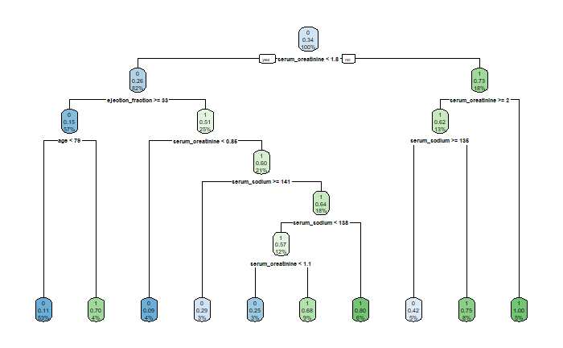

```r
tree = rpart(DEATH_EVENT ~ ., data = train, method = "class")
rpart.plot(tree, extra = 106)
```

Za parametar **extra** funkcije *rpart.plot* stavili smo vrednost 106 jer je u pitanju binarna klasifikacija.

Sa grafika vidimo da listovi stabla predstavljaju predikciju modela tj. kojoj klasi smatra da odredjeni ispitanik pripada. Čvorovi unutar stabla predstavljaju test za odredjeni atribut i u zavisnosti od (ne)ispunjenosti tog testa, kroz drvo se spuštamo niz desnu odnosno levu granu.

**Predikcija korišćenjem stabla odlučivanja:**

```r
decision_tree_prediction = predict(tree, test, type = 'class')
```

```r
decision_tree_prediction
```

```
  2   3   7  17  21  34  37  41  44  45  54  56  67  75  76  77  81  84  91 103 116 122 123 125 130 131 136 139 150
  0   1   1   1   1   1   1   1   0   0   0   1   1   1   0   0   0   1   0   0   0   0   0   1   0   0   0   0   0
157 168 170 177 179 185 196 197 199 202 203 212 216 219 225 232 233 236 238 244 252 253 264 268 278 279 280 282 284
  0   1   0   0   0   1   0   0   0   0   0   0   0   0   1   0   0   0   1   0   0   0   0   0   0   0   0   0   0
290 291 296 308 313
  1   0   0   1   0
Levels: 0 1
```

```r
table_mat = table(test$DEATH_EVENT, decision_tree_prediction)
table_mat
```

```
   decision_tree_prediction
     0  1
  0 40  6
  1  5 12
```

Model je tačne predikcije doneo za 52 ispitanika (40 stvarno nisu preminuli, 12 jeste). Šest ispitanika je pogrešno klasifikovao kao preminule, a pet pogrešno da nisu.

Naš model služi da prediktuje da li može doći do smrtnog ishoda. To znači da nam najveću opasnost i problem predstavlja ukoliko model pogrešno predvidi da ispitanik nije u smrtnoj opasnosti. Na osnovu toga, kao glavnu metriku za ovaj i sledeće modele koristićemo **recall**.

**Recall** predstvlja metriku koja nam govori koliko je pozitivnih izlaza zapravo predvideo kao takve. Drugačije se naziva true positive rate (TPR). Izračunava se na sledeći način: TP/(TP+FN).

Izračunajmo recall modela stabla odlučivanja:

```r
decision_tree_recall=table_mat[2,"1"]/(table_mat[2,"1"]+table_mat[2,"0"])
decision_tree_recall
```

```
[1] 0.7058824
```

Ukoliko nas zanima tačnost modela (*accuracy*), to izračunavamo na sledeći način:

```r
decision_tree_accuracy = sum(diag(table_mat))/sum(table_mat)
decision_tree_accuracy
```

```
[1] 0.8253968
```

Kao što vidimo, ovaj model uopšte nije loš. U nastavku ćemo razmatrati još neke modele i odabrati najefikasniji.

## Naivni Bayes

Naivni Bayes (eng. *Naive Bayes*) je tehnika klasifikovanja kojom svakom ispitaniku dodeljujemo labelu, pri čemu je ona u obliku vektora vrednosti obeležja. Labela uzima vrednost iz nekog konačnog skupa, u našem slučaju 0 ili 1.

Bayes klasifikatori posmatraju svako obeležje kao nezavisno od svih ostalih. Svaki od obeležja nezavisno doprinosi verovatnoći da ispitanik pripada odredjenoj klasi.

Rezultujuća kolona mora da bude faktor, pa ćemo to i odraditi.

```r
library(e1071)
library(caret)
library(caretEnsemble)
library(psych)
library(GGally)
library(randomForest)
```

```r
x = train[,-5]
y = as.factor(train$DEATH_EVENT)
```

```r
bayesModel = train(x,y,'nb',trControl=trainControl(method='cv',number=10))
bayesModel
```

```
Naive Bayes

250 samples
  4 predictor
  2 classes: '0', '1'

No pre-processing
Resampling: Cross-Validated (10 fold)
Summary of sample sizes: 225, 225, 225, 225, 224, 225, ...
Resampling results across tuning parameters:

  usekernel  Accuracy   Kappa
  FALSE      0.7195897  0.2838174
   TRUE      0.7155897  0.3285380

Tuning parameter 'fL' was held constant at a value of 0
Tuning parameter 'adjust' was held constant at a value of 1
Accuracy was used to select the optimal model using the largest value.
The final values used for the model were fL = 0, usekernel = FALSE and adjust = 1.
```

Prilikom treniranja korišćena je krosvalidaciona metoda u 10 koraka (možemo videti iz prosledjenih parametara funkcije train, **method=‘cv’** i **number=10**)

```r
bayesModelPred = predict(bayesModel,test)
```

```r
bayesModelPred
```

```
 [1] 0 1 1 1 0 0 1 1 0 0 0 1 0 0 0 0 0 0 0 1 0 0 0 1 1 0 0 0 0 0 1 0 0 0 0 0 0 0 0 0 0 0 0 0 0 0 0 0 0 0 0 0 0 0 0 0 1
[58] 0 1 0 0 0 0
Levels: 0 1
```

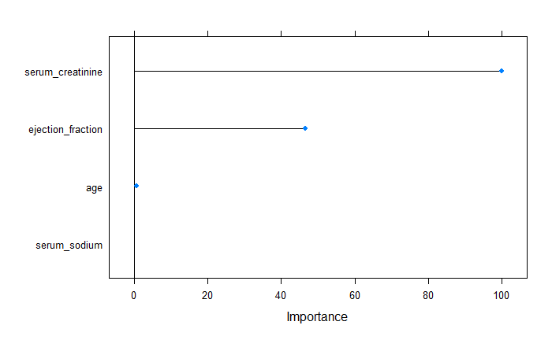

```r
X = varImp(bayesModel)
plot(X)
```

```r
matrix = table(test$DEATH_EVENT,bayesModelPred)
matrix
```

```
   bayesModelPred
     0  1
  0 42  4
  1  9  8
```

Vidimo da je model ispravno predvideo za za 50 ispitanika.Devetoro njih je pogresno klasifikovao kao žive, a četvoro pogrešno kao preminule.

Izračunajmo recall modela naivnog Bayes-a:

```r
bayes_recall=matrix[2,"1"]/(matrix[2,"1"]+matrix[2,"0"])
bayes_recall
```

```
[1] 0.4705882
```

Ukoliko nas zanima tačnost modela (*accuracy*):

```r
bayes_accuracy = sum(diag(matrix))/sum(matrix)
bayes_accuracy
```

```
[1] 0.7936508
```

## Logistička regresija

Logistička regresija predstavlja još jedan metod za klasifikaciju koji ima široku upotrebu. Vraća verovatnoću pripadnosti nekoj klasi, što znači da je u pitanju verovatnosni klasifikator. Verovatnoću pripadnosti nekoj klasi potom treba transformisati u konkretne izlaze (0 ili 1 - nije preminuo ili preminuo) korišćenjem odabrane vrednosti praga. Modelom logističke regresije opisaćemo vezu između prediktora, a potom ćemo ga oceniti i uporediti sa prethodnim modelima. Prvo ćemo učitati potrebne pakete:

```r
library("caTools")    # For Logistic regression
library("ROCR")       # For ROC curve to evaluate model
```

Logističku regresiju možemo implementirati korišćenjem **glm()** funkcije.

```r
logisticModel <- glm(DEATH_EVENT ~ age + ejection_fraction + serum_creatinine + serum_sodium,
                      data = train,
                      family = "binomial")
```

```r
summary(logisticModel)
```

```
Call:
glm(formula = DEATH_EVENT ~ age + ejection_fraction + serum_creatinine +
    serum_sodium, family = "binomial", data = train)

Deviance Residuals:
    Min       1Q   Median       3Q      Max
-2.3404  -0.7893  -0.5229   0.9311   2.2464

Coefficients:
                  Estimate Std. Error z value Pr(>|z|)
(Intercept)        3.87731    4.60057   0.843 0.399346
age                0.04607    0.01318   3.496 0.000473 ***
ejection_fraction -0.06341    0.01502  -4.221 2.43e-05 ***
serum_creatinine   0.60492    0.16632   3.637 0.000276 ***
serum_sodium      -0.04338    0.03339  -1.299 0.193861
---
Signif. codes:  0 ‘***’ 0.001 ‘**’ 0.01 ‘*’ 0.05 ‘.’ 0.1 ‘ ’ 1

(Dispersion parameter for binomial family taken to be 1)

    Null deviance: 320.52  on 249  degrees of freedom
Residual deviance: 262.11  on 245  degrees of freedom
AIC: 272.11

Number of Fisher Scoring iterations: 4
```

Potom vršimo predikciju i dobijene verovatnoće pripadnosti klasi transformišemo u 0 ili 1 (0 ako je vrednost <= 0.5, 1 ako je vrednost > 0.5, pri čemu je 0.5 vrednost praga).

```r
logisticModelPred <- predict(logisticModel, test, type = "response")
logisticModelPred <- ifelse(logisticModelPred > 0.5, 1, 0)
```

```r
logisticModelPred
```

```
  2   3   7  17  21  34  37  41  44  45  54  56  67  75  76  77  81  84  91 103 116 122 123 125 130 131 136 139 150
  0   1   1   0   1   0   0   1   0   0   0   1   0   1   0   0   0   0   0   1   0   0   0   1   0   0   0   0   0
157 168 170 177 179 185 196 197 199 202 203 212 216 219 225 232 233 236 238 244 252 253 264 268 278 279 280 282 284
  0   1   0   0   0   0   0   0   0   0   0   0   0   0   0   0   0   0   1   0   0   0   0   0   0   0   0   1   0
290 291 296 308 313
  0   0   0   0   0
```

```r
table_logreg = table(test$DEATH_EVENT, logisticModelPred)
table_logreg
```

```
   logisticModelPred
     0  1
  0 42  4
  1 10  7
```

Model je tačne predikcije doneo za 49 ispitanika od ukupno 63, od čega je u žive svrstao 42 ispitanika koji su zaista živi i 7 ispitanika u preminule koji su zaista preminuli. 4 ispitanika je pogrešno klasifikovano u grupu preminulih, a 10 u grupu živih.

Izračunaćemo recall ovog modela:

```r
logreg_recall=table_logreg[2,"1"]/(table_logreg[2,"1"]+table_logreg[2,"0"])
logreg_recall
```

```
[1] 0.4117647
```

Kao i tačnost (accuracy):

```r
logreg_accuracy = sum(diag(table_logreg))/sum(table_logreg)
logreg_accuracy
```

```
[1] 0.7777778
```

## Upoređivanje modela

Pozabavićemo se i ROC krivom. ROC kriva pokazuje odnos između TPR (True Positive Rate) i FPR (False Positive Rate). True Positive Rate predstavlja udeo pozitivnih ishoda koji su korekno identifikovani kao takvi, dok False Positive Rate pokazuje koji udeo čine ishodi koji su zapravo negativni, ali su lažno svrstani u pozitivne.

### ROC kriva za stablo odlučivanja

```r
ROCPredTree <- prediction(as.numeric(decision_tree_prediction), test$DEATH_EVENT)
ROCPerTree <- performance(ROCPredTree, measure = "tpr", x.measure = "fpr")

auc <- performance(ROCPredTree, measure = "auc")
auc <- auc@y.values[[1]]
auc
```

```
[1] 0.7877238
```

Iscrtavanje krive:

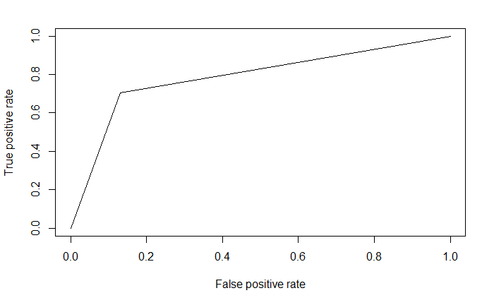

```r
plot(ROCPerTree)
```

```r
plot(ROCPerTree, colorize = TRUE, print.cutoffs.at = seq(0.1, by = 0.1), main = "Stablo odlučivanja - ROC kriva")
abline(a = 0, b = 1)
```

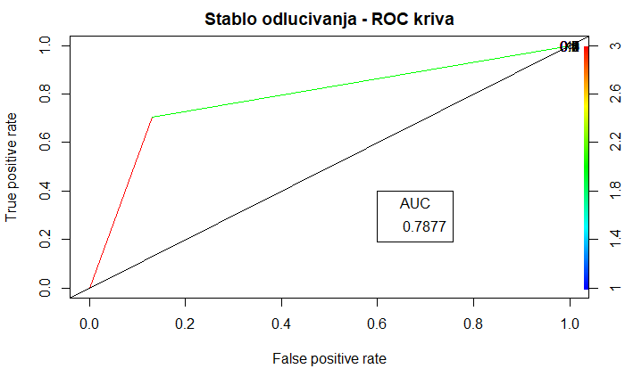

```r
auc <- round(auc, 4)
legend(.6, .4, auc, title = "AUC", cex = 1)
```

### ROC kriva za naivni Bayes

```r
ROCPredBayes <- prediction(as.numeric(bayesModelPred), test$DEATH_EVENT)
ROCPerBayes <- performance(ROCPredBayes, measure = "tpr", x.measure = "fpr")

auc <- performance(ROCPredBayes, measure = "auc")
auc <- auc@y.values[[1]]
auc
```

```
[1] 0.6918159
```

Iscrtavanje krive:

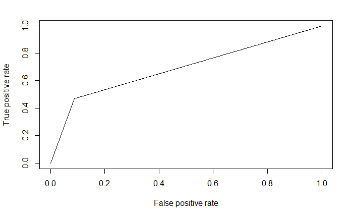

```r
plot(ROCPerBayes)
```

```r
plot(ROCPerBayes, colorize = TRUE, print.cutoffs.at = seq(0.1, by = 0.1), main = "Naivni Bayes - ROC kriva")
abline(a = 0, b = 1)
```

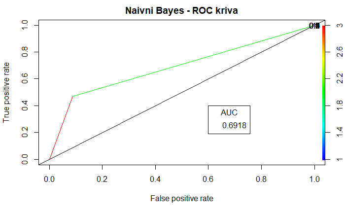

```r
auc <- round(auc, 4)
legend(.6, .4, auc, title = "AUC", cex = 1)
```

### ROC kriva za logističku regresiju

```r
ROCPred <- prediction(logisticModelPred, test$DEATH_EVENT)
ROCPer <- performance(ROCPred, measure = "tpr", x.measure = "fpr")

auc <- performance(ROCPred, measure = "auc")
auc <- auc@y.values[[1]]
auc
```

```
[1] 0.6624041
```

Iscrtavanje krive:

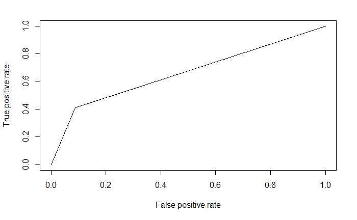

```r
plot(ROCPer)
```

```r
plot(ROCPer, colorize = TRUE, print.cutoffs.at = seq(0.1, by = 0.1), main = "Logistička regresija - ROC kriva")
abline(a = 0, b = 1)
```

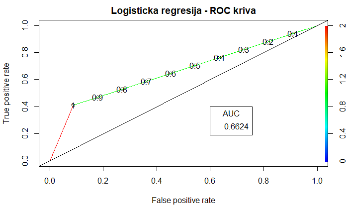

```r
auc <- round(auc, 4)
legend(.6, .4, auc, title = "AUC", cex = 1)
```

Ukoliko se naš model nađe na dijagonali koju možemo videti na grafiku, ili ispod, to znači da njegovo predviđanje nije ništa bolje od običnog bacanja novčića, odnosno slučajne klasifikacije. Idealan slučaj bio bi da True Positive Rate bude 1, a False Positive Rate 0, jer bi to značilo da model vrši ispravnu predikciju za 100% slučajeva koje imamo u testnom skupu. Međutim, modeli ne mogu biti savršeni i očekivano je da prave greške, ali je cilj da to bude u što manjoj meri. Kao što možemo videti, površina ispod grafika (AUC) iznosi 0.66 od 1 koliko je maksimalno moguće (idealni klasifikator ima AUC=1), i samim tim možemo zaključiti da je model nešto bolji od bacanja novčića, što je daleko od idealnog.

Na osnovu vrednosti za recall i accuracy, kao i upravo analizirane ROC krive i površine ispod nje, zaključujemo da je model logističke regresije lošiji prethodnih. Od tri predstavljena modela, najbolje se pokazao model stabla odlučivanja.

## Zaključak

Analizom kreiranih modela, došli smo do saznanja da je za problem koji rešavamo najpogodnije koristiti **model stabla odlučivanja**, koji se pokazao kao najbolji na osnovu izračunatih metrika.